In this problem we will consider the daily U.S. Dollar-Euro exchange rate, daily, 4 Jan 1999 to 27 Jan 2015 (*n* = 4115).

```r
data <- read.csv("http://ptrckprry.com/course/forecasting/data/euro.csv")
date <- as.Date(data$date)
euro <- data$euro
```

## Part A

Here is a time-series plot of Euro.

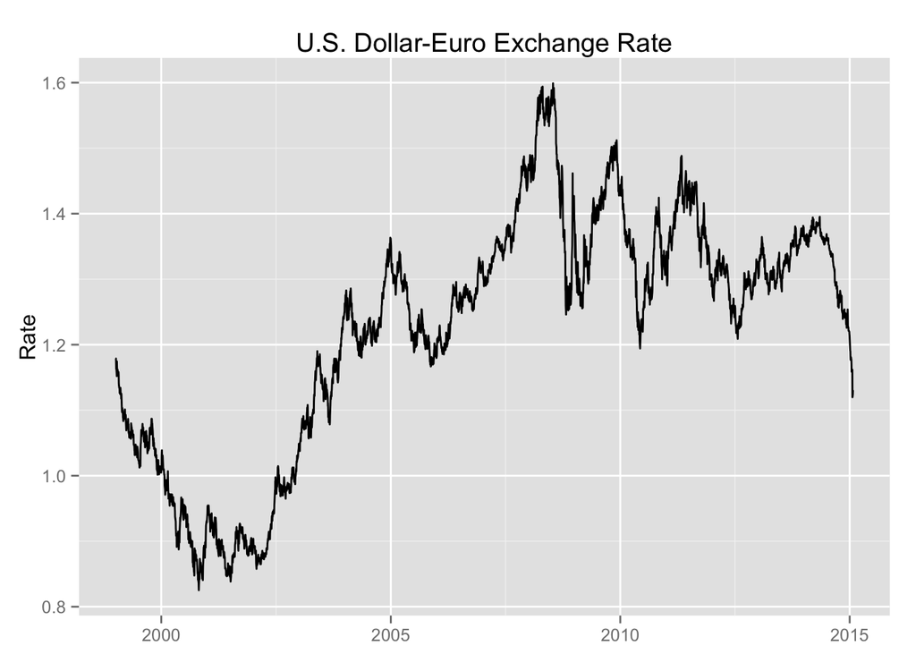

```r
library(ggplot2)
ggplot() + geom_line(aes(date, euro)) + xlab(NULL) + ylab("Rate") + labs(title = "U.S. Dollar-Euro Exchange Rate")
```

**Does a straight-line model seem appropriate?** A straight-line model does not seem appropriate here because there is too much volatility in the US Dollar-Euro exchange rate. Furthermore, there isn’t a consistent long term trend.

## Part B

Here, we fit two models and predict the value at 28 Jan 2015 (time = 4116). In the first model, we fit to observations 1 to 700. In the second model, we fit to observations 701 to 4115.

```r
time <- 1:length(euro) # create the time variable

model1 <- lm(euro ~ time, subset=1:700)
summary(model1)
```

```
##
## Call:
## lm(formula = euro ~ time, subset = 1:700)
##
## Residuals:
##       Min        1Q    Median        3Q       Max
## -0.097114 -0.020562  0.001242  0.023713  0.092279
##
## Coefficients:
##               Estimate Std. Error t value Pr(>|t|)
## (Intercept)  1.104e+00  2.733e-03  404.07   <2e-16 ***
## time        -3.873e-04  6.755e-06  -57.33   <2e-16 ***
## ---
## Signif. codes:  0 '***' 0.001 '**' 0.01 '*' 0.05 '.' 0.1 ' ' 1
##
## Residual standard error: 0.03612 on 698 degrees of freedom
## Multiple R-squared:  0.8248, Adjusted R-squared:  0.8246
## F-statistic:  3287 on 1 and 698 DF,  p-value: < 2.2e-16
```

```r
model2 <- lm(euro ~ time, subset=701:4115)
summary(model2)
```

```
##
## Call:
## lm(formula = euro ~ time, subset = 701:4115)
##
## Residuals:
##      Min       1Q   Median       3Q      Max
## -0.31572 -0.07160  0.00040  0.07642  0.31876
##
## Coefficients:
##              Estimate Std. Error t value Pr(>|t|)
## (Intercept) 1.054e+00  5.283e-03  199.59   <2e-16 ***
## time        9.265e-05  2.030e-06   45.63   <2e-16 ***
## ---
## Signif. codes:  0 '***' 0.001 '**' 0.01 '*' 0.05 '.' 0.1 ' ' 1
##
## Residual standard error: 0.117 on 3413 degrees of freedom
## Multiple R-squared:  0.3789, Adjusted R-squared:  0.3787
## F-statistic:  2082 on 1 and 3413 DF,  p-value: < 2.2e-16
```

Here are the predicted values and 95% prediction intervals for the two models:

```r
newdata <- data.frame(time = 4116)
predict(model1, newdata, interval = 'prediction', level = .95)
```

```
##          fit        lwr        upr
## 1 -0.4897896 -0.5765626 -0.4030167
```

```r
predict(model2, newdata, interval = 'prediction', level = .95)
```

```
##        fit      lwr      upr
## 1 1.435802 1.206322 1.665282
```

## Part C

Here, we superimpose the fitted lines from both models on the time series plot.

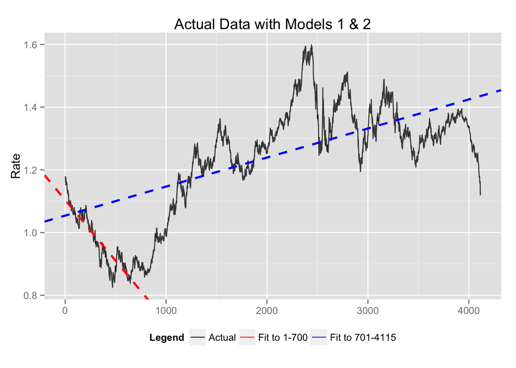

```r
cols <- c("Actual" = "black", "Fit to 1-700" = "red", "Fit to 701-4115" = "blue")

ggplot() + geom_line(aes(time, euro, colour = 'Actual'), alpha = .75) +

  geom_abline(aes(colour = "Fit to 1-700"), intercept = 1.104e+00,
              slope = -3.873e-04, size = 1, linetype = 'dashed') +

  geom_abline(aes(colour = "Fit to 701-4115"), intercept = 1.054e+00,
              slope = 9.265e-05,  size = 1, linetype = 'dashed') +
  scale_colour_manual(name = "Legend", values= cols) +
  xlab(NULL) + ylab("Rate") + labs(title = 'Actual Data with Models 1 & 2') +
  theme(legend.position = "bottom")
```